# Handling the peculiarities of marine movement data

## 5.2 Using a state-space model to filter out the error, but not regularise

One way around this issue of time resolution is to use a state-space model that predict the location at the same time as the time the data is observed. This process allows to account for the error of Argos data without having to regularize the data. If the subsequent analysis allow for irregular time intervals, this may be a good option.

There are many state-space models that could be used to model the Argos error, including the crawl model explored above for the narwhal data, but here we use the model from the R package `aniMotum`.

One of the main choice one must make is which model to fit. Here we can model the underlying movement with a simple random walk (`model = rw`), a correlated random walk (`model = crw`, more directed), and the time-varying move persistence model (`model = mp`). Here, we can see that the penguins have very different movement when close to the colony than when travelling to foraging. As such, the time-varying move persistence model, which allow the animal to change less to more directed appears the best option.

We also need to tell the function `fit_smm` which columns contain the id of the animal, coordinates, the date, and the location quality.

The function `fit_ssm` applies some prefiltering before applying the state-space model for data. One of the prefiltering arguments is `vmax`, which set the maximum travel rate (m/s). Here, we set it to 50 km/hr, which is large so as not to remove too many locations. To see the default values for things like maximum travel rate and min allowable time difference, look at the help file (`?fit_ssm`).

Importantly, unlike `crawl`, which using an analytically solution for the continuous time movement model, `animotum` uses an approximation. In essence, we choose a discrete time interval at which we want to use to make our approximation of continuous time. The smaller this time interval the more accurate the approximation is. In essence, we want to set the argument `time.step` to a small value. Here we choose 1 hour, which is may not be fine scale enough, but the smaller the time interval the longer it will take to fit the model. Thus, to be able to run the code during the tutorial, we chose a coarser time interval

```r
gentoo_mpi <- fit_ssm(gentoo_tracks,
                      id = "ID",
                      coord = c("Longitude", "Latitude"),
                      date = "time",
                      lc = "Qual",
                      model = "mp",
                      time.step = 1,
                      vmax = (50*1000)/(60*60))
```

[output not shown]

```r
head(gentoo_mpi)
```

```
## # A tibble: 3 × 5
##   id     ssm           converged pdHess pmodel
##   <chr>  <named list>  <lgl>     <lgl>  <chr>
## 1 170902 <mp_ssm [15]> TRUE      TRUE   mp
## 2 170905 <mp_ssm [15]> TRUE      TRUE   mp
## 3 170914 <mp_ssm [15]> TRUE      TRUE   mp
```

While we are fitting the model to all three gentoo penguins at the same, the current package version fit the model independently to each individual (i.e., parameters are not shared across the individual).

The function `summary` provides information on the convergence, the AICc, and the parameter estimates for each individual.

```r
summary(gentoo_mpi)
```

```
##  Animal id Model Time n.obs n.filt n.fit n.pred n.rr converged   AICc
##     170902    mp    1   404     31   373   1885    .      TRUE 5062.6
##     170905    mp    1   305     23   282   1623    .      TRUE 4454.7
##     170914    mp    1   350     51   299   1810    .      TRUE 4544.7
##
## --------------
## 170902
## --------------
##  Parameter Estimate Std.Err
##      rho_p   -0.708  0.0661
##    sigma_x   0.5072  0.0452
##    sigma_y   0.6418  0.0477
##      rho_o   0.4501  0.0848
##      tau_x   0.1264  0.0082
##      tau_y   0.1003  0.0074
##    sigma_g   0.7181  0.0769
##
## --------------
## 170905
## --------------
##  Parameter Estimate Std.Err
##      rho_p   0.6071  0.1144
##    sigma_x    0.312  0.0358
##    sigma_y   0.5963   0.045
##      rho_o  -0.1169   0.097
##      tau_x   0.3988  0.0245
##      tau_y   0.2085  0.0134
##    sigma_g   0.4409  0.1409
##
## --------------
## 170914
## --------------
##  Parameter Estimate Std.Err
##      rho_p  -0.7703  0.0683
##    sigma_x    0.315  0.0359
##    sigma_y    0.532  0.0418
##      rho_o  -0.0513  0.0954
##      tau_x   0.4231  0.0223
##      tau_y   0.1428  0.0103
##    sigma_g   0.5528  0.0426
```

Here, the model converged for all tracks. Convergence can be hard to get at times, and you may need to play with the `time.step`.

The package also provides easy plotting functions. When we use `type = 1`, we can see the latitude and longitude separately. When we use `type = 2` we see the tracks. If we want to use the estimated location at the time of the observation, you want to specify the argument `what` to “fitted”.

```
## $`170902`
```

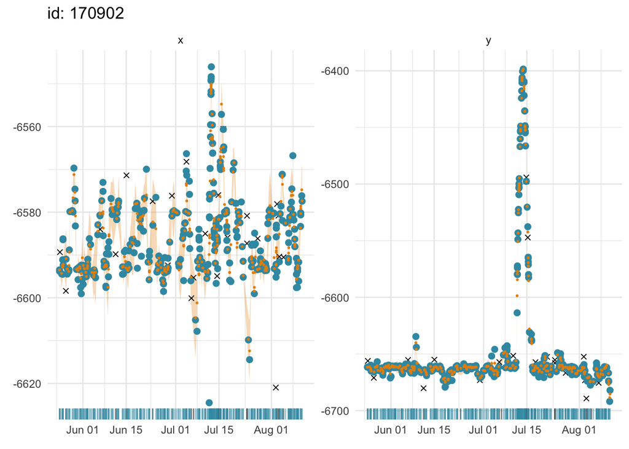

```
##
## $`170905`
```

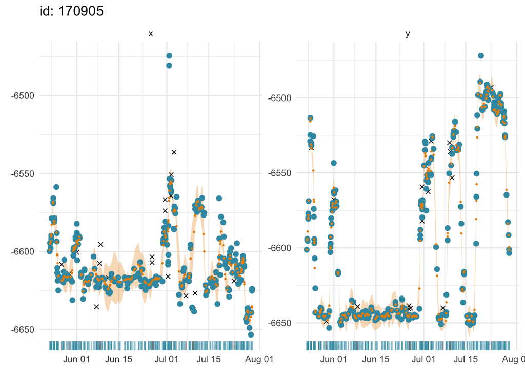

```
##
## $`170914`
```

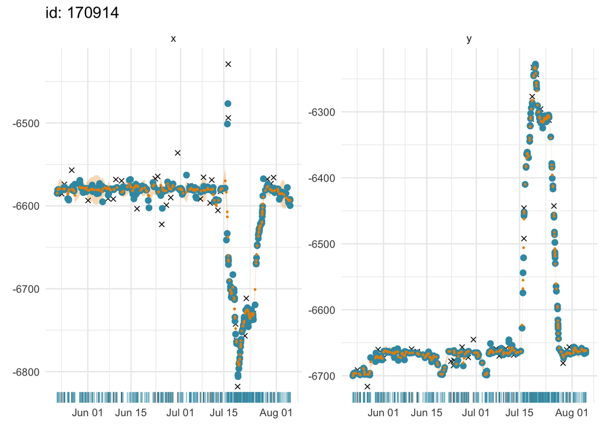

```r
plot(gentoo_mpi, what ="fitted", type=1, ask = FALSE)
```

```
## $`170902`
```

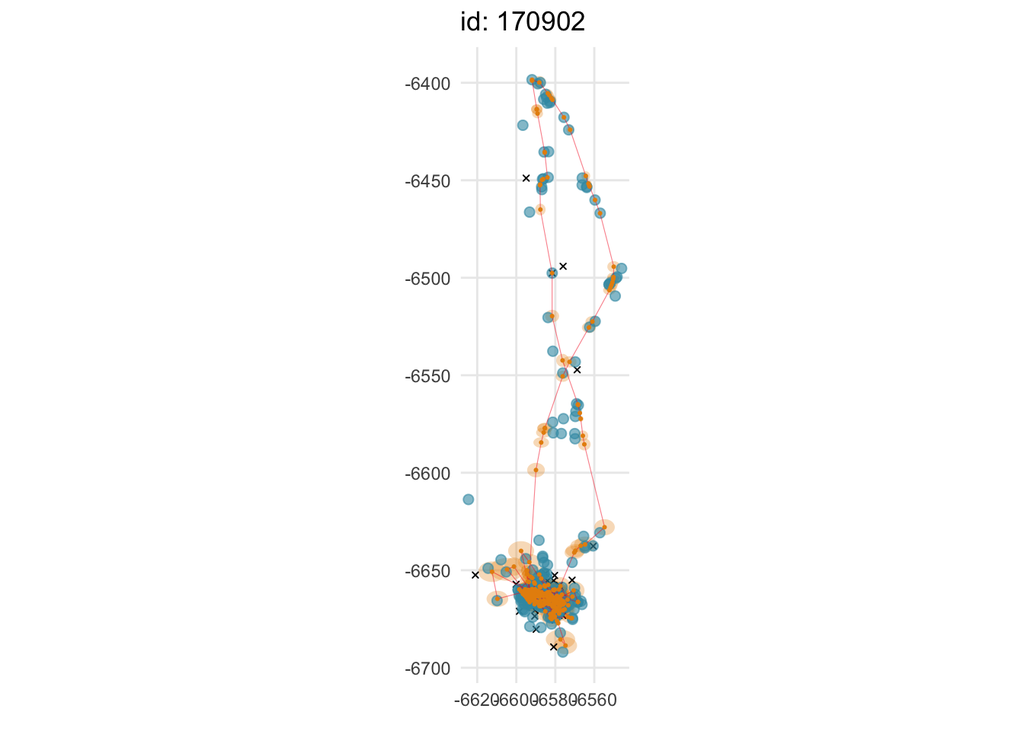

```
##
## $`170905`
```

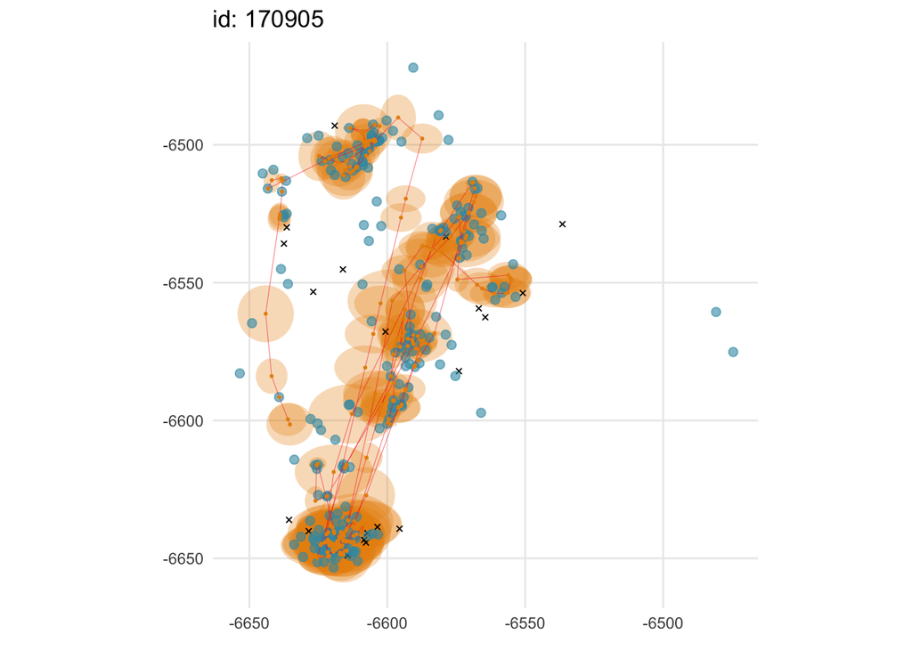

```
##
## $`170914`
```

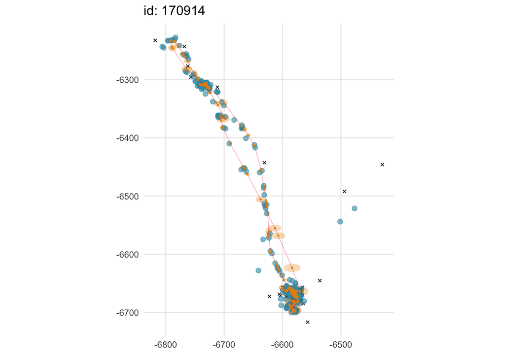

```r
plot(gentoo_mpi, what ="fitted", type=2, ask = FALSE)
```

In both sets of plots, the blue circles are the observations used in the state-space model, the x are the observations that were removed during the prefiltering, and the orange circle and line is the fitted track returned by the model. In the type 1 plots, the rug display the observation timing.

We can use the function `map` to create a nicer map of the movement data. Here are the individuals are plotted in the same figure, there is a base map of land masses, and the movement persistence is represented by the colour gradient, with yellow representing more persistent movement.

```
## using map scale: 10
```

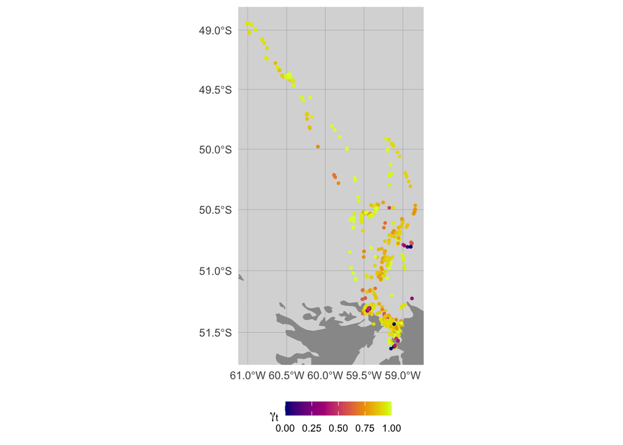

```r
aniMotum::map(gentoo_mpi, what = "fitted")
```

By default, the `map` function normalise the move persistence value for each individual independently so that each track range between 0 and 1. To apply the normalisation so that the magnitudes of move persistence are preserved across individuals you can do the following:

```
## using map scale: 10
```

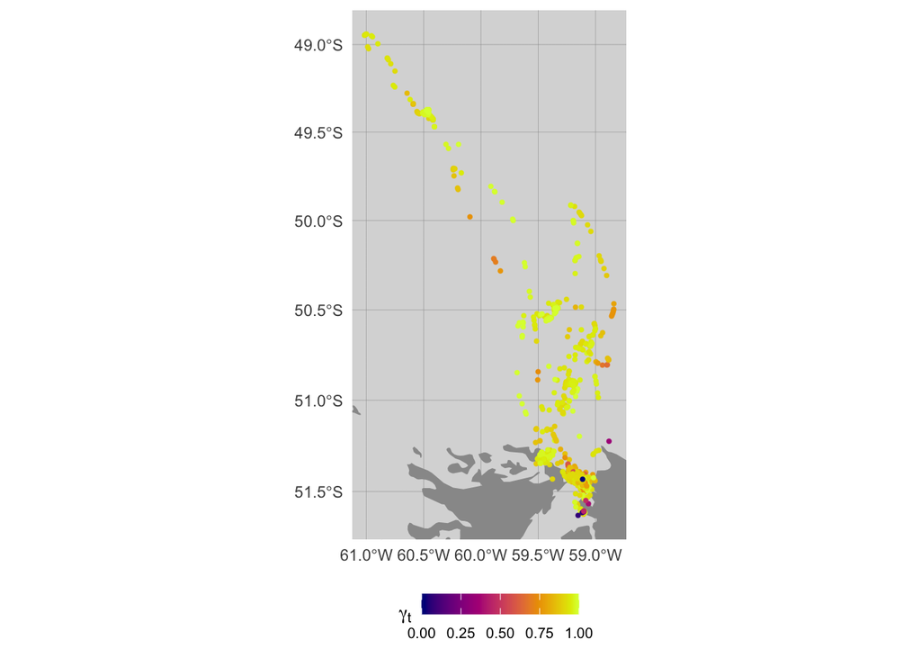

```r
aniMotum::map(gentoo_mpi, what = "fitted", normalise = TRUE, group = TRUE)
```

To be able to analyse the data further or to be able to plot it yourself, you can graph the data and make it into a tibble using the function `grab`.

```r
gentoo_mpi_t <- grab(gentoo_mpi, what = "fitted")
head(gentoo_mpi_t)
```

```
## # A tibble: 6 × 11
##   id     date                  lon   lat      x      y  x.se  y.se logit_g
##   <chr>  <dttm>              <dbl> <dbl>  <dbl>  <dbl> <dbl> <dbl>   <dbl>
## 1 170902 2018-05-24 10:09:38 -59.2 -51.4 -6593. -6662. 0.195 0.129    4.06
## 2 170902 2018-05-24 10:11:07 -59.2 -51.4 -6593. -6662. 0.196 0.134    4.06
## 3 170902 2018-05-25 02:12:32 -59.2 -51.4 -6594. -6661. 1.60  1.43     4.07
## 4 170902 2018-05-25 10:14:34 -59.2 -51.4 -6593. -6663. 1.57  1.36     4.06
## 5 170902 2018-05-25 11:31:21 -59.2 -51.4 -6593. -6663. 1.37  1.17     4.06
## 6 170902 2018-05-25 11:32:20 -59.2 -51.4 -6593. -6663. 1.37  1.16     4.06
## # ℹ 2 more variables: logit_g.se <dbl>, g <dbl>
```

We can see here that we now have different names for some of the columns like `id`, `date`. These are the names used by the function `fit_ssm`. We also now have the new location provided by the state-space model in `lon` and `lat` and move persistence `g`. We also get the coordinates and their standard error and the logit gamma with its standard error.

We can now plot the data ourselves.

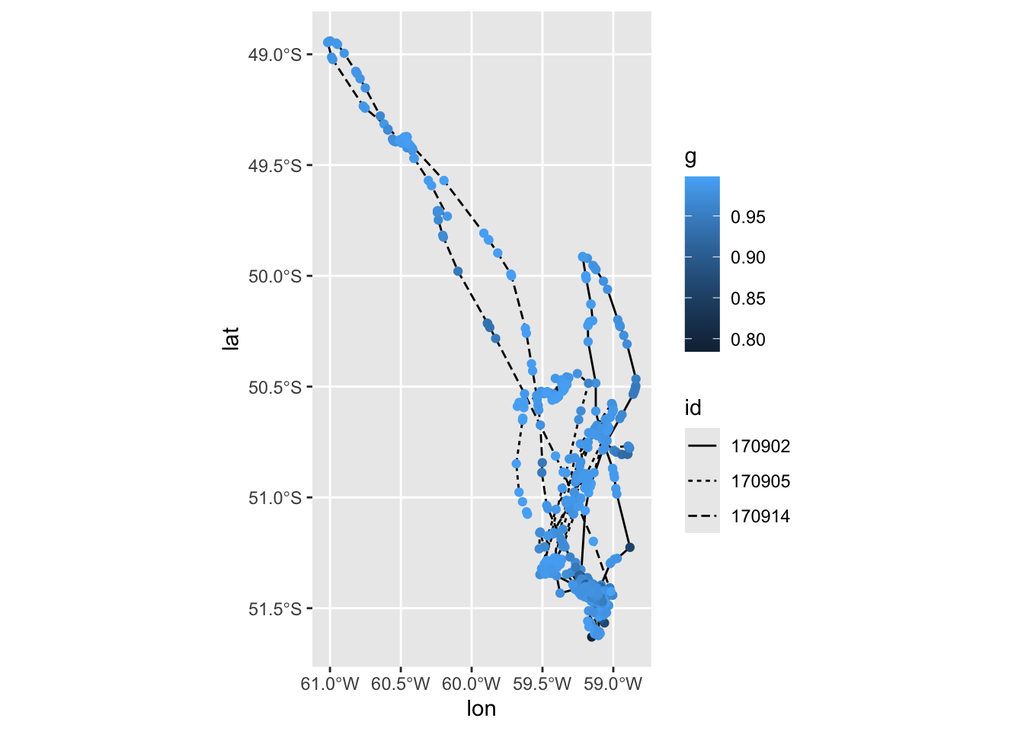

```r
ggplot() +
  geom_spatial_path(data =  gentoo_mpi_t,
                    aes(x = lon, y = lat, lty = id),
                    crs = 4326) +
  geom_spatial_point(data =  gentoo_mpi_t,
                    aes(x = lon, y = lat, col = g),
                    crs = 4326) +
  coord_sf(crs = 4326)
```

It is important to check whether the model is appropriate for the data. To do so, we can look at one-step ahead residuals. This will take a few minute to run.

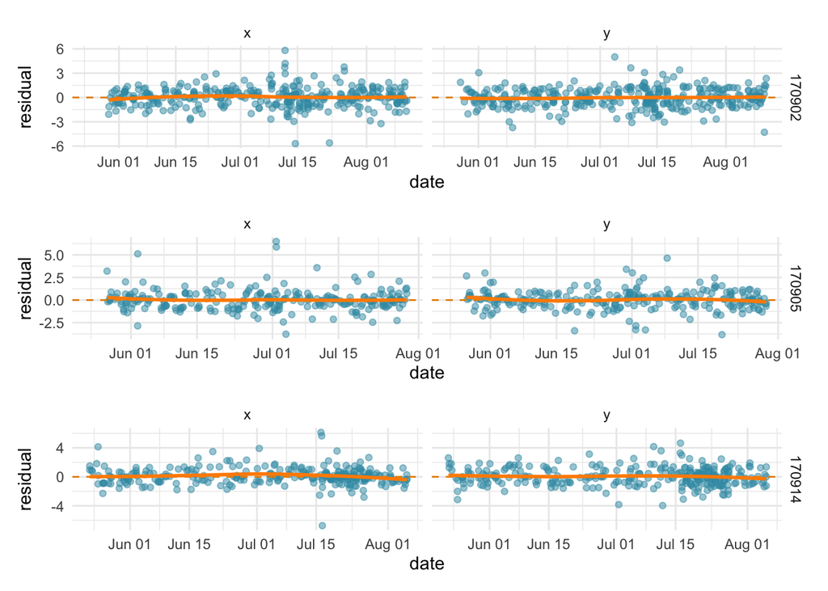

```r
res.crw <- osar(gentoo_mpi)
plot(res.crw, type = "ts")
```

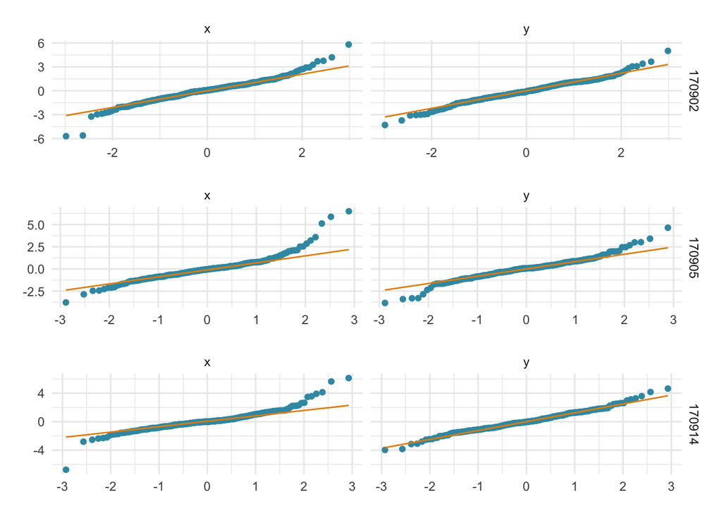

```r
plot(res.crw, type = "qq")
```

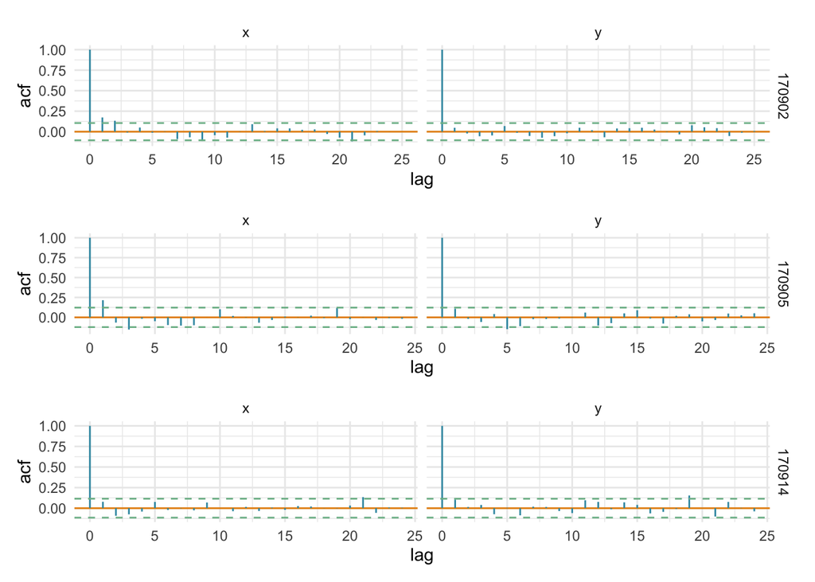

```r
plot(res.crw, type = "acf")
```

We can see here that the model is not perfect. There is still a bit of autocorrelation and the model is not great for very small and large values. But overall it’s looking not too bad.

## 5.3 Using a state-space model to account for Argos error and regularise

First, let us explore the raw regular track with points at the time scale we used when fitting the model. To be able to extract that information, we simply set the argument `what` to “predicted”. This will return predicted locations at times where we don’t necessarily have observations.

```
## $`170902`
```

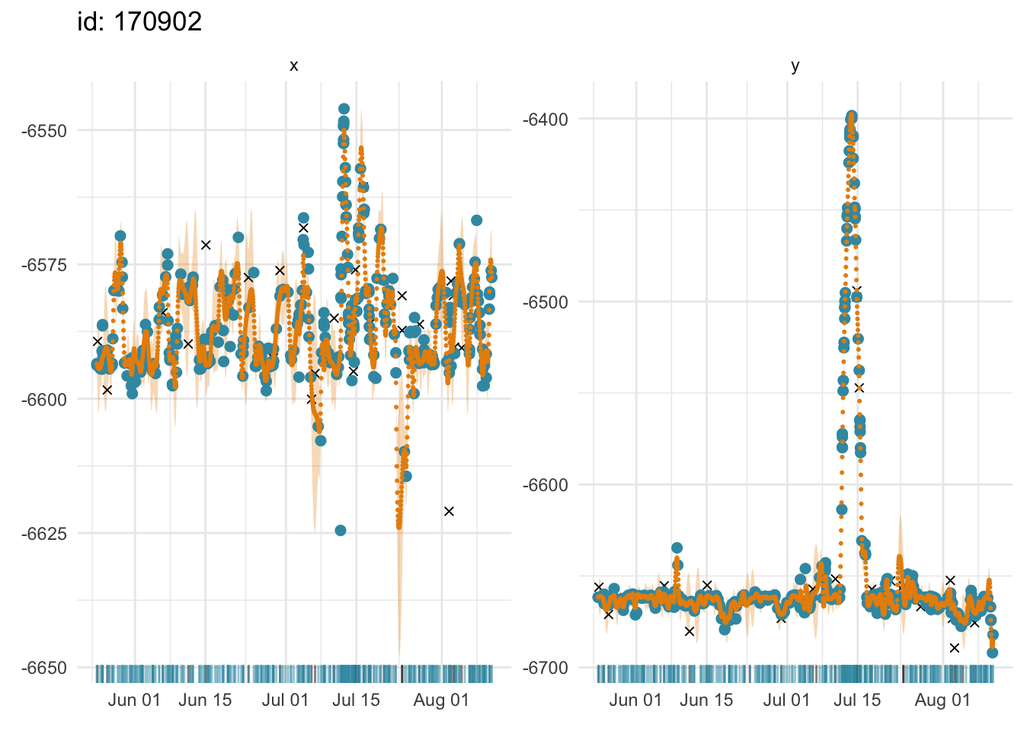

```
##
## $`170905`
```

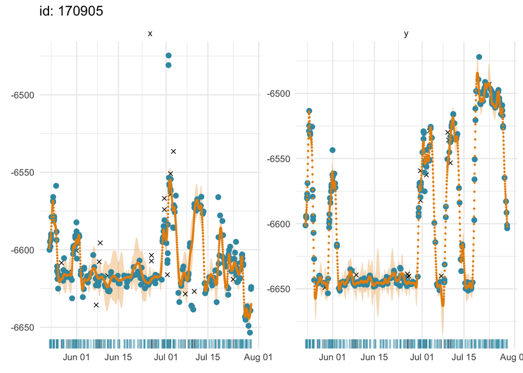

```
##
## $`170914`
```

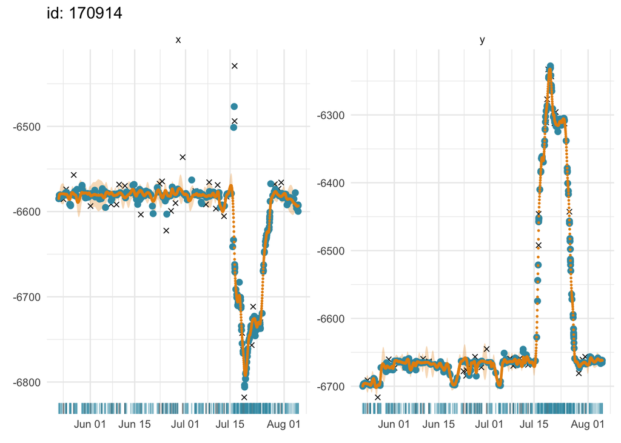

```r
plot(gentoo_mpi, what ="predicted", type=1, ask=FALSE)
```

```
## $`170902`
```

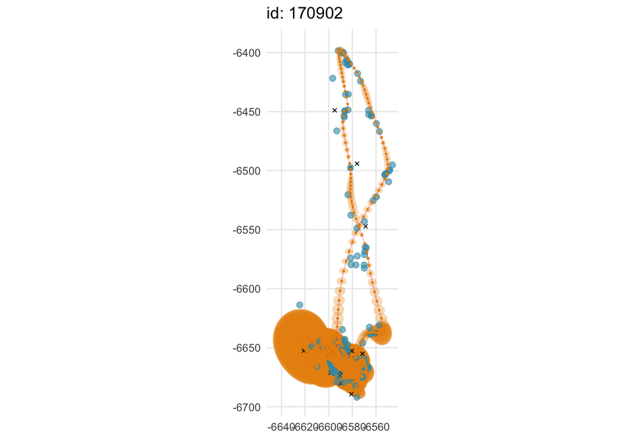

```
##
## $`170905`
```

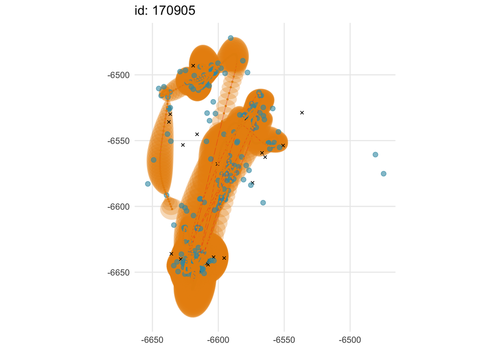

```
##
## $`170914`
```

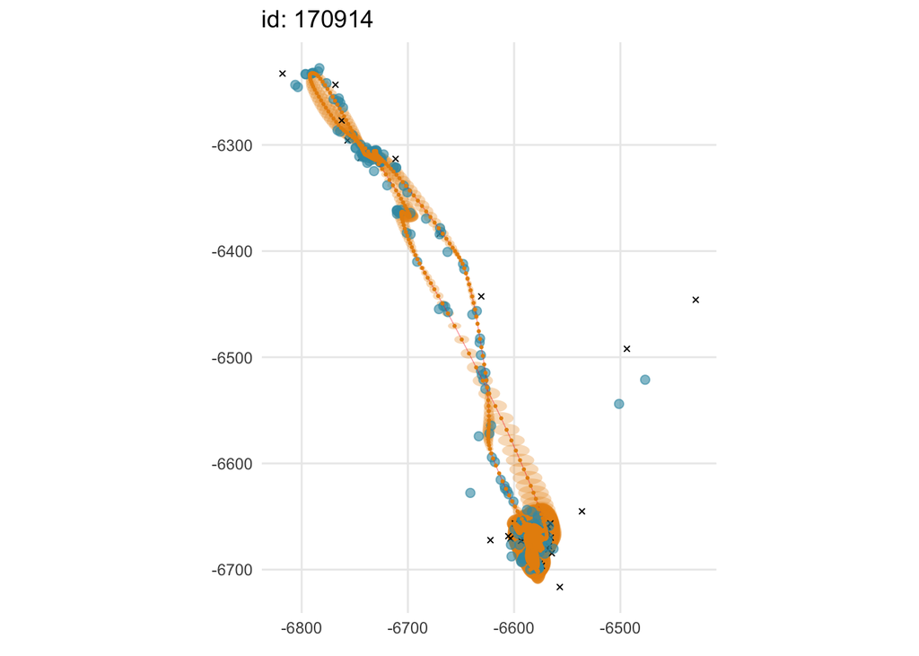

```r
plot(gentoo_mpi, what ="predicted", type=2, ask=FALSE)
```

Map the tracks.

```
## using map scale: 10
```

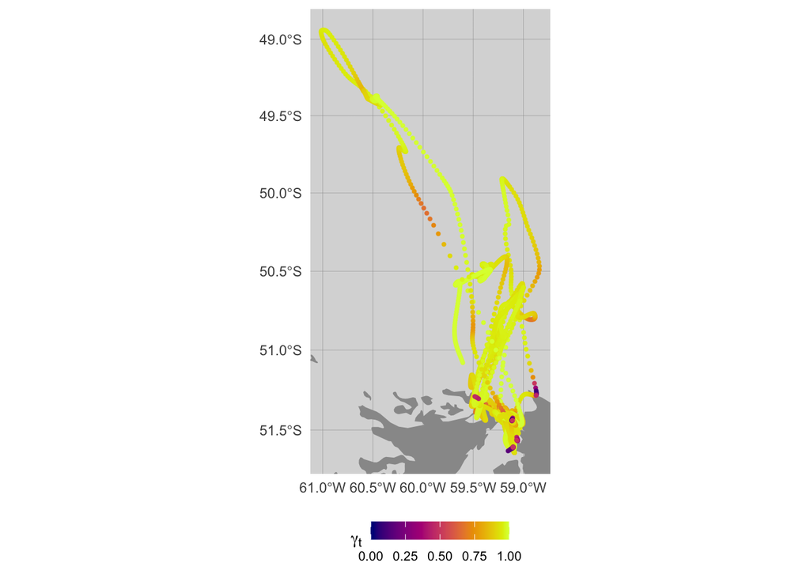

```r
aniMotum::map(gentoo_mpi, what = "predicted", normalise = TRUE, group = TRUE)
```

We can see that we get much more points than our observations and that when there are data gaps, the predicted tracks are likely much straighter than they the real track of the gentoo penguins.

Here, we will grab the predicted tracks and subsample them for other analyses. If you don’t use the argument `what = "predicted"`, grab will return the fitted data at irregular time intervals.

```r
gentoo_mpr_t <- grab(gentoo_mpi, what = "predicted")
head(gentoo_mpr_t)
```

```
## # A tibble: 6 × 11
##   id     date                  lon   lat      x      y  x.se  y.se logit_g
##   <chr>  <dttm>              <dbl> <dbl>  <dbl>  <dbl> <dbl> <dbl>   <dbl>
## 1 170902 2018-05-24 10:09:00 -59.2 -51.4 -6593. -6662. 0.195 0.131    4.06
## 2 170902 2018-05-24 11:09:00 -59.2 -51.4 -6594. -6662. 1.09  1.36     4.06
## 3 170902 2018-05-24 12:09:00 -59.2 -51.4 -6594. -6662. 1.99  2.48     4.06
## 4 170902 2018-05-24 13:09:00 -59.2 -51.4 -6594. -6661. 2.73  3.40     4.06
## 5 170902 2018-05-24 14:09:00 -59.2 -51.4 -6594. -6661. 3.31  4.13     4.06
## 6 170902 2018-05-24 15:09:00 -59.2 -51.4 -6594. -6661. 3.74  4.65     4.06
## # ℹ 2 more variables: logit_g.se <dbl>, g <dbl>
```

Notice that the locations are now at every 1 hour. If we want them every 4 hours, we simply take one row every 4.

```r
gentoo_mpr_4hr <- gentoo_mpr_t[seq(1, nrow(gentoo_mpr_t), by=4), ]
```

We can now plot the subsampled data.

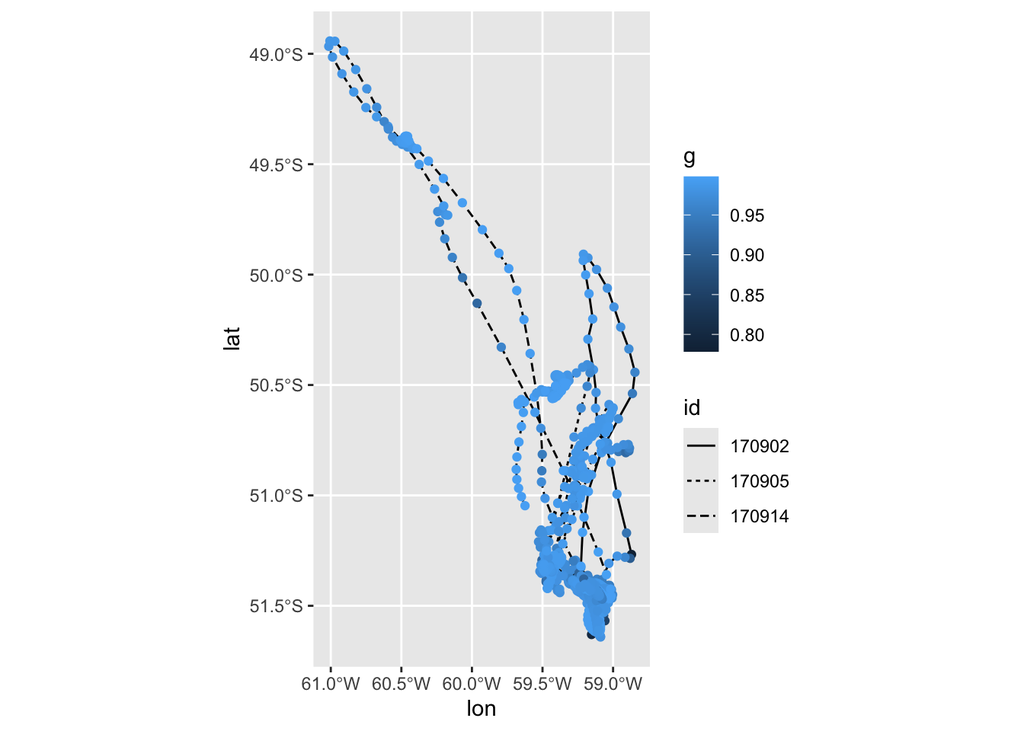

```r
ggplot() +
  geom_spatial_path(data =  gentoo_mpr_4hr,
                    aes(x = lon, y = lat, lty = id),
                    crs = 4326) +
  geom_spatial_point(data =  gentoo_mpr_4hr,
                    aes(x = lon, y = lat, col = g),
                    crs = 4326) +
  coord_sf(crs = 4326)
```

## 5.4 Multiple simulated tracks for multiple imputation

To be able to do multiple imputation, we could simulate from the posterior. Here we do 4, just to be able to vizualise it. This process is similar to the process we did for the narwhal data above.

According to the vignette of `aniMotum` they state: “Posterior simulations from an SSM fit provide a useful characterization of track uncertainty. The sim_post function provides an efficient method for simulating tracks from the joint uncertainty of the estimated locations.” This will take time to run.

```r
set.seed(2025)
psim <- sim_post(gentoo_mpi, what = "predicted", reps = 4)

# Grab the data to be able to use it
gentoo_post <- psim %>%
  unnest(cols = psims) %>%
  mutate(rep = factor(rep))
```

Plots the tracks created by the simulations.

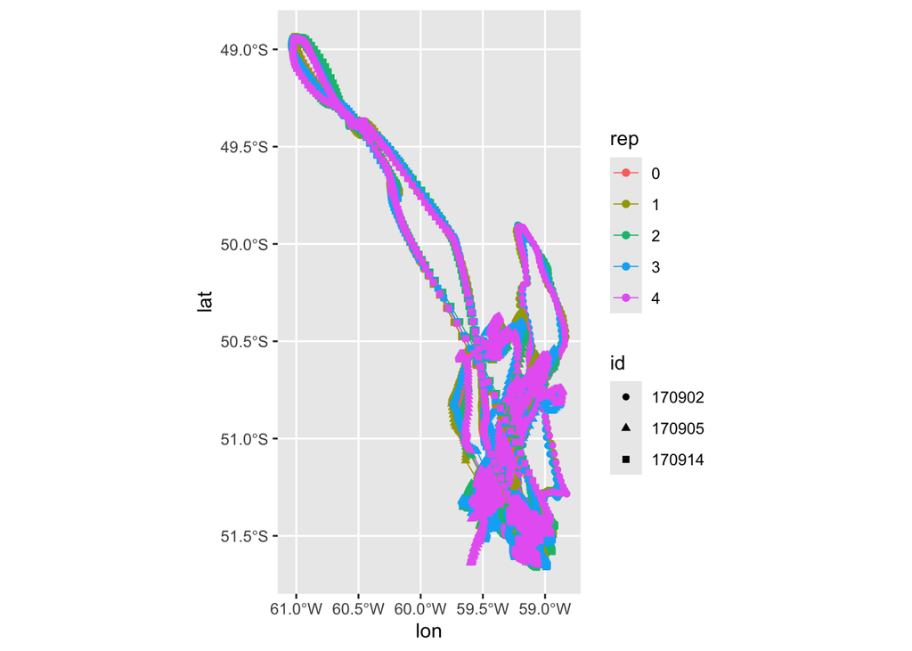

```r
ggplot() +
  geom_spatial_path(data = gentoo_post,
                    aes(x = lon, y = lat, colour = rep),
                    lwd = 0.3,
                    crs = 4326) +
  geom_spatial_point(data = gentoo_post,
                    aes(x = lon, y = lat, pch = id, colour = rep),
                    crs = 4326) +
  coord_sf(crs = 4326)
```

We can see the slightly different paths. Replicate of 0 is the original track produce by the state-space model.

# 6 Literature cited

Johnson, DS, JM London, MA Lea, JW Durban. 2008. Continuous-time correlated random walk model for animal telemetry data. Ecology 89: 1208-1215